# ML_Types

## Document classification and model analysis using Naive Bayes, k Nearest Neighbors, Support Vector Machines, and Artificial Neural Networks

### Liam Black Rohrer

```
Train: 428 articles, 13518 features
Test: 106  articles, 13518 features
  Id      Category                                     Article (first 60 chars)                                              Top-5 features (word: tfidf weight)
1976          tech lifestyle governs mobile choice faster better funkier hardwa           phone: 0.313, bjorn: 0.308, dr: 0.229, ericsson: 0.225, cameras: 0.221
1797 entertainment french honour director parker british film director sir alan             vabres: 0.309, parker: 0.276, alan: 0.218, french: 0.205, sir: 0.203
1866 entertainment fockers fuel festive film chart comedy meet fockers topped f            fockers: 0.347, meet: 0.305, christmas: 0.304, day: 0.191, box: 0.183
1153 entertainment housewives lift channel 4 ratings debut us television hit de audience: 0.311, housewives: 0.271, channel: 0.255, share: 0.236, january: 0.212
 342 entertainment u2 desire number one u2 three prestigious grammy awards hit                    band: 0.262, u2: 0.200, bono: 0.187, album: 0.149, rock: 0.128
```

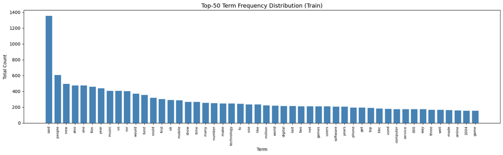

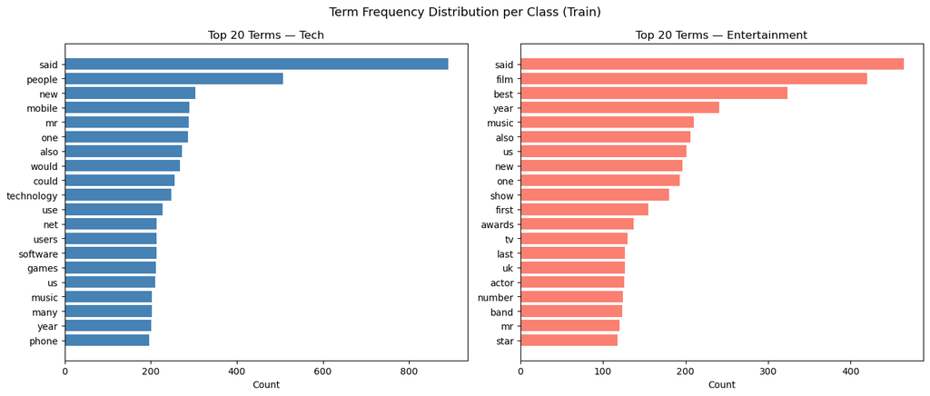

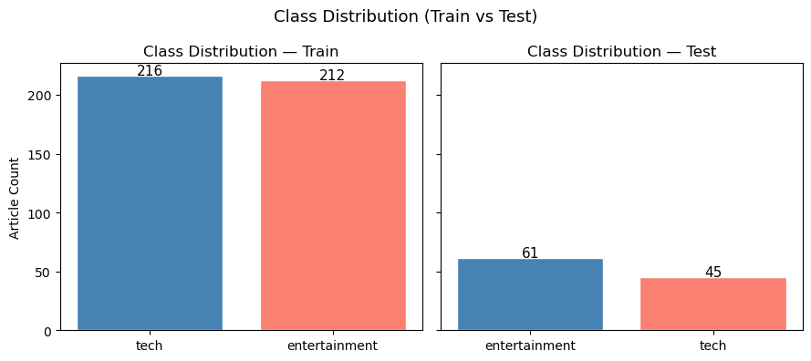

```python
import pandas as pd
import numpy as np
import matplotlib.pyplot as plt
from sklearn.feature_extraction.text import TfidfVectorizer

train_raw = pd.read_csv('train.csv')
test_raw = pd.read_csv('test.csv')

#Vectorization
vectorizer = TfidfVectorizer()
X_train = vectorizer.fit_transform(train_raw['Article'])   # fit and transform
X_test = vectorizer.transform(test_raw['Article'])        # transform only

#Report sizes
print(f"Train: {X_train.shape[0]} articles, {X_train.shape[1]} features")
print(f"Test: {X_test.shape[0]}  articles, {X_test.shape[1]} features")

#Show 5 example articles with their TF-IDF feature vectors
feature_names = vectorizer.get_feature_names_out()

example_rows = []
for i in range(5):
    sparse_row = X_train[i]
    nonzero_idx = sparse_row.nonzero()[1]
    nonzero_vals = sparse_row.data
    top5_idx = nonzero_idx[np.argsort(nonzero_vals)[::-1][:5]]
    top5_vals = np.asarray(sparse_row[0, top5_idx].todense()).flatten()

    example_rows.append({
        'Id': train_raw['Id'].iloc[i],
        'Category': train_raw['Category'].iloc[i],
        'Article (first 60 chars)': train_raw['Article'].iloc[i][:60],
        'Top-5 features (word: tfidf weight)': ', '.join(f"{feature_names[j]}: {v:.3f}" for j, v in zip(top5_idx, top5_vals))
    })

example_df = pd.DataFrame(example_rows)
print(example_df.to_string(index=False))


#Term frequency analysis — three plots

from sklearn.feature_extraction.text import CountVectorizer

cv = CountVectorizer()
X_counts = cv.fit_transform(train_raw['Article'])
words = cv.get_feature_names_out()

#Plot 1: Top-50 term frequency distribution
word_freq = X_counts.sum(axis=0).A1
freq_series = pd.Series(word_freq, index=words).sort_values(ascending=False)
top50 = freq_series.head(50)

fig, ax = plt.subplots(figsize=(16, 5))
ax.bar(range(50), top50.values, color='steelblue', edgecolor='white')
ax.set_xticks(range(50))
ax.set_xticklabels(top50.index, rotation=90, fontsize=8)
ax.set_title('Top-50 Term Frequency Distribution (Train)', fontsize=13)
ax.set_xlabel('Term')
ax.set_ylabel('Total Count')
plt.tight_layout()
plt.savefig('task1_top50_freq.png', dpi=120)
plt.show()

#Plot 2: Term frequency distribution per class
tech_articles = train_raw[train_raw['Category'] == 'tech']['Article']
ent_articles = train_raw[train_raw['Category'] == 'entertainment']['Article']

# Use same vocabulary as above (already fit)
tech_freq = pd.Series(cv.transform(tech_articles).sum(axis=0).A1, index=words)
ent_freq = pd.Series(cv.transform(ent_articles).sum(axis=0).A1, index=words)

top_n = 20
fig, axes = plt.subplots(1, 2, figsize=(14, 6))

tech_top = tech_freq.nlargest(top_n)
axes[0].barh(tech_top.index[::-1], tech_top.values[::-1], color='steelblue')
axes[0].set_title(f'Top {top_n} Terms — Tech', fontsize=12)
axes[0].set_xlabel('Count')

ent_top = ent_freq.nlargest(top_n)
axes[1].barh(ent_top.index[::-1], ent_top.values[::-1], color='salmon')
axes[1].set_title(f'Top {top_n} Terms — Entertainment', fontsize=12)
axes[1].set_xlabel('Count')

plt.suptitle('Term Frequency Distribution per Class (Train)', fontsize=13)
plt.tight_layout()
plt.savefig('task1_per_class_freq.png', dpi=120)
plt.show()

#Plot 3: Class distribution (train and test sets)
fig, axes = plt.subplots(1, 2, figsize=(9, 4), sharey=True)

train_counts = train_raw['Category'].value_counts()
test_counts = test_raw['Category'].value_counts()

axes[0].bar(train_counts.index, train_counts.values, color=['steelblue', 'salmon'], edgecolor='white')
axes[0].set_title('Class Distribution — Train', fontsize=12)
axes[0].set_ylabel('Article Count')
for bar, val in zip(axes[0].patches, train_counts.values):
    axes[0].text(bar.get_x() + bar.get_width()/2, bar.get_height() + 1, str(val), ha='center', fontsize=11)

axes[1].bar(test_counts.index, test_counts.values, color=['steelblue', 'salmon'], edgecolor='white')
axes[1].set_title('Class Distribution — Test', fontsize=12)
for bar, val in zip(axes[1].patches, test_counts.values):
    axes[1].text(bar.get_x() + bar.get_width()/2, bar.get_height() + 1, str(val), ha='center', fontsize=11)

plt.suptitle('Class Distribution (Train vs Test)', fontsize=13)
plt.tight_layout()
plt.savefig('task1_class_dist.png', dpi=120)
plt.show()
```

### Task 1(a):

- Train set: 428 articles, 13,518 TF-IDF features.
- Test set: 106 articles, same 13,518 features (vocabulary fixed from train).
- We use TfidfVectorizer because TF-IDF downweights very common words that appear across most articles, making thefeatures more discriminative than raw counts.
- The vectorizer is fit on the training set only; applying it to the test set ensures no information leakage.

### Task 1(b):

- The top-50 plot shows a long-tail distribution with a small number of words dominating total frequency, while most words are rare.
- The per-class plots show clear vocabulary separation with tech articles dominated by terms like "people", "mobile", and "technology", while entertainment articles favour terms like "film", "music", "award".
- The class distribution is relatively balanced in both the training set (216 tech to 212 entertainment) and test set (45 tech to 61 entertainment), so accuracy and F1 will tell similar stories.

```
Top 20 predictive words for entertainment:
['film', 'best', 'said', 'show', 'band', 'music', 'year', 'awards', 'us', 'award', 'actor', 'album', 'star', 'chart', 'tv', 'also', 'number', 'oscar', 'top', 'new']

Top 20 predictive words for tech:
['said', 'people', 'mobile', 'software', 'games', 'phone', 'net', 'users', 'technology', 'mr', 'microsoft', 'virus', 'computer', 'broadband', 'new', 'use', 'could', 'would', 'digital', 'game']

Top 20 most discriminative words (tech vs entertainment):
['mobile', 'software', 'users', 'microsoft', 'games', 'net', 'technology', 'virus', 'phone', 'broadband', 'computer', 'phones', 'spam', 'mail', 'firms', 'use', 'spyware', 'online', 'pc', 'internet']
```

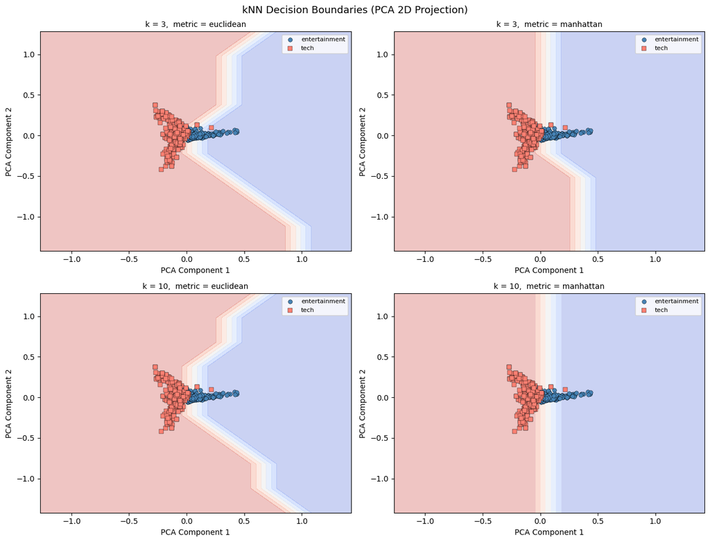

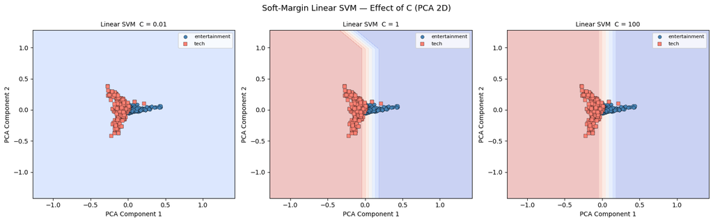

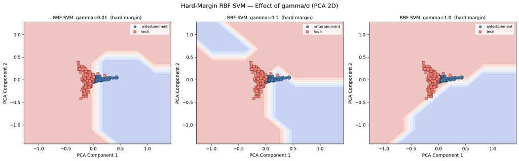

```
h =  2:  final loss = 0.3936
h =  5:  final loss = 0.4427
h = 20:  final loss = 0.4551
h = 40:  final loss = 0.4081
```

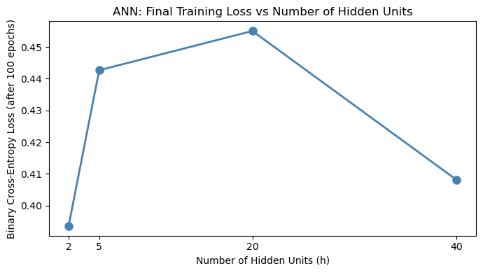

```python
#TASK 2: Classification Models

import warnings
warnings.filterwarnings('ignore')
from sklearn.naive_bayes import MultinomialNB
from sklearn.neighbors import KNeighborsClassifier
from sklearn.svm import SVC
from sklearn.neural_network import MLPClassifier
from sklearn.decomposition import PCA
from sklearn.preprocessing import LabelEncoder

le = LabelEncoder()
y_train = le.fit_transform(train_raw['Category'])
y_test = le.transform(test_raw['Category'])


#Task 2(a): Naive Bayes

nb = MultinomialNB()
nb.fit(X_train, y_train)

#Log P(word|class) for each class — shape (n_classes, n_features)
log_probs = nb.feature_log_prob_
class_labels = le.classes_

#(i) Top 20 most predictive words per class
for i, cls in enumerate(class_labels):
    top20_idx = np.argsort(log_probs[i])[::-1][:20]
    top20_words = [feature_names[j] for j in top20_idx]
    print(f"\nTop 20 predictive words for {cls}:")
    print(top20_words)

#(ii) Top 20 most discriminative words (maximize P(word|tech) / P(word|ent))
# In log space this is log P(word|tech) - log P(word|ent)
tech_idx = list(class_labels).index('tech')
ent_idx = list(class_labels).index('entertainment')
log_ratio = log_probs[tech_idx] - log_probs[ent_idx]
top20_disc_idx = np.argsort(log_ratio)[::-1][:20]
top20_disc_words = [feature_names[j] for j in top20_disc_idx]
print("\nTop 20 most discriminative words (tech vs entertainment):")
print(top20_disc_words)


#Task 2(b): kNN

#Reduce to 2D with PCA so we can plot a decision boundary
pca = PCA(n_components=2, random_state=42)
X_train_2d = pca.fit_transform(X_train.toarray())
X_test_2d = pca.transform(X_test.toarray())

def plot_decision_boundary(clf, X, y, title, ax):
    h = 0.3
    x_min, x_max = X[:, 0].min() - 1, X[:, 0].max() + 1
    y_min, y_max = X[:, 1].min() - 1, X[:, 1].max() + 1
    xx, yy = np.meshgrid(np.arange(x_min, x_max, h), np.arange(y_min, y_max, h))
    Z = clf.predict(np.c_[xx.ravel(), yy.ravel()]).reshape(xx.shape)
    ax.contourf(xx, yy, Z, alpha = 0.3, cmap ='coolwarm')
    colors = ['steelblue', 'salmon']
    markers = ['o', 's']
    for cls, color, marker in zip([0, 1], colors, markers):
        mask = y == cls
        ax.scatter(X[mask, 0], X[mask, 1], c = color, marker = marker, label = le.classes_[cls], edgecolors = 'k', linewidths = 0.3, s = 30)
    ax.set_title(title, fontsize=10)
    ax.set_xlabel('PCA Component 1')
    ax.set_ylabel('PCA Component 2')
    ax.legend(fontsize = 8)

#Plot four combinations: k = 3 and 10, metric = euclidean and manhattan
fig, axes = plt.subplots(2, 2, figsize=(13, 10))
configs = [(3, 'euclidean'), (3, 'manhattan'), (10, 'euclidean'), (10, 'manhattan')]

for ax, (k, metric) in zip(axes.flat, configs):
    knn = KNeighborsClassifier(n_neighbors = k, metric = metric)
    knn.fit(X_train_2d, y_train)
    plot_decision_boundary(knn, X_train_2d, y_train, f'k = {k},  metric = {metric}', ax)

plt.suptitle('kNN Decision Boundaries (PCA 2D Projection)', fontsize = 13)
plt.tight_layout()
plt.savefig('task2b_knn_boundaries.png', dpi = 120)
plt.show()


#Task 2(c): SVM

#(i) Soft-margin linear SVM — vary C
fig, axes = plt.subplots(1, 3, figsize = (16, 5))
for ax, C in zip(axes, [0.01, 1, 100]):
    svm = SVC(kernel='linear', C = C)
    svm.fit(X_train_2d, y_train)
    plot_decision_boundary(svm, X_train_2d, y_train, f'Linear SVM  C = {C}', ax)

plt.suptitle('Soft-Margin Linear SVM — Effect of C (PCA 2D)', fontsize = 13)
plt.tight_layout()
plt.savefig('task2c_svm_linear.png', dpi=120)
plt.show()

#(ii) Hard-margin RBF kernel SVM — vary gamma (≈ 1/2σ²)
#Large C used to approximate a hard margin
fig, axes = plt.subplots(1, 3, figsize=(16, 5))
for ax, gamma in zip(axes, [0.01, 0.1, 1.0]):
    svm = SVC(kernel = 'rbf', C = 1e6, gamma = gamma)
    svm.fit(X_train_2d, y_train)
    plot_decision_boundary(svm, X_train_2d, y_train, f'RBF SVM  gamma={gamma}  (hard margin)', ax)

plt.suptitle('Hard-Margin RBF SVM — Effect of gamma/σ (PCA 2D)', fontsize = 13)
plt.tight_layout()
plt.savefig('task2c_svm_rbf.png', dpi = 120)
plt.show()


# Task 2(d): ANN — Effect of number of hidden units

# Train a single hidden layer MLP with: initial weights drawn uniformly from [0, 0.1], learning rate = 0.01, 100 epochs
hidden_units_list = [2, 5, 20, 40]
final_losses = []

for h in hidden_units_list:
    mlp = MLPClassifier(
        hidden_layer_sizes = (h,),
        activation = 'relu',
        solver= 'sgd',
        learning_rate = 'constant',
        learning_rate_init = 0.01,
        max_iter = 100,
        random_state = 42,
    )
    mlp.fit(X_train, y_train)
    final_losses.append(mlp.loss_)
    print(f"h = {h:2d}:  final loss = {mlp.loss_:.4f}")

fig, ax = plt.subplots(figsize=(7, 4))
ax.plot(hidden_units_list, final_losses, marker = 'o', color = 'steelblue', linewidth = 2, markersize = 8)
ax.set_title('ANN: Final Training Loss vs Number of Hidden Units', fontsize = 12)
ax.set_xlabel('Number of Hidden Units (h)')
ax.set_ylabel('Binary Cross-Entropy Loss (after 100 epochs)')
ax.set_xticks(hidden_units_list)
plt.tight_layout()
plt.savefig('task2d_ann_loss.png', dpi = 120)
plt.show()
```